# DESeq2 Tutorial

Yun Wang / Franziska Metge

This tutorial follows http://master.bioconductor.org/packages/release/workflows/vignettes/rnaseqGene/inst/doc/rnaseqGene.html

## Contents

- Preparing count matrices
- The DESeqDataSet object
- Exploratory analysis and visualization
- Differential expression analysis
- Plotting results

## Preparing count matrices

We will use an example dataset from the *airway* package. It contains four human [airway](http://bioconductor.org/packages/release/data/experiment/html/airway.html) smooth muscle cell lines with two conditions each (untreated control and dexamethasone treated).  
https://www.ncbi.nlm.nih.gov/pubmed/24926665

```bash
# to align your raw reads stored in fastq files, you can use for example STAR to align your reads to the reference genome

STAR --genomeDir <STAR/index/directory>
     --runThreadN 10
     --readFilesIn <reads_R1.fastq.gz> [<reads_R2.fastq.gz>]
     --outFileNamePrefix <sample_name.>
     --outSAMtype BAM SortedByCoordinate
     --readFilesCommand zcat

# this call produces a binary alignment file in BAM format with reads sorted by coordinates
```

```r
# loading all libraries
library("airway")
library("Rsamtools")
library("GenomicFeatures")
library("GenomicAlignments")
library("BiocParallel")
library("magrittr")
library("DESeq2")
library("vsn")
library("dplyr")
library("ggplot2")
library("pheatmap")
library("RColorBrewer")
library("PoiClaClu")
library("ggbeeswarm")
library("apeglm")
library("genefilter")
library("AnnotationDbi")
library("org.Hs.eg.db")
library("ReportingTools")
library("Gviz")
library("sva")
library("RUVSeq")
library("fission")
```

We will use they data from the [airway](http://bioconductor.org/packages/release/data/experiment/html/airway.html) package, which contains 8 samples with a reduced number of reads and already aligned.

```r
# source("https://bioconductor.org/biocLite.R")
# biocLite("airway")

library(airway)

# get the package's directory
indir <- system.file("extdata", package="airway", mustWork=TRUE)

# look at the files in the directory
list.files(indir)
```

```
##  [1] "GSE52778_series_matrix.txt"        "Homo_sapiens.GRCh37.75_subset.gtf"
##  [3] "quants"                            "sample_table.csv"
##  [5] "SraRunInfo_SRP033351.csv"          "SRR1039508_subset.bam"
##  [7] "SRR1039509_subset.bam"             "SRR1039512_subset.bam"
##  [9] "SRR1039513_subset.bam"             "SRR1039516_subset.bam"
## [11] "SRR1039517_subset.bam"             "SRR1039520_subset.bam"
## [13] "SRR1039521_subset.bam"
```

```r
csvfile <- file.path(indir, "sample_table.csv")
sampleTable <- read.csv(csvfile, row.names = 1)
sampleTable
```

```
##            SampleName    cell   dex albut        Run avgLength Experiment
## SRR1039508 GSM1275862  N61311 untrt untrt SRR1039508       126  SRX384345
## SRR1039509 GSM1275863  N61311   trt untrt SRR1039509       126  SRX384346
## SRR1039512 GSM1275866 N052611 untrt untrt SRR1039512       126  SRX384349
## SRR1039513 GSM1275867 N052611   trt untrt SRR1039513        87  SRX384350
## SRR1039516 GSM1275870 N080611 untrt untrt SRR1039516       120  SRX384353
## SRR1039517 GSM1275871 N080611   trt untrt SRR1039517       126  SRX384354
## SRR1039520 GSM1275874 N061011 untrt untrt SRR1039520       101  SRX384357
## SRR1039521 GSM1275875 N061011   trt untrt SRR1039521        98  SRX384358
##               Sample    BioSample
## SRR1039508 SRS508568 SAMN02422669
## SRR1039509 SRS508567 SAMN02422675
## SRR1039512 SRS508571 SAMN02422678
## SRR1039513 SRS508572 SAMN02422670
## SRR1039516 SRS508575 SAMN02422682
## SRR1039517 SRS508576 SAMN02422673
## SRR1039520 SRS508579 SAMN02422683
## SRR1039521 SRS508580 SAMN02422677
```

```r
filenames <- file.path(indir, paste0(sampleTable$Run, "_subset.bam"))
file.exists(filenames)
```

```
## [1] TRUE TRUE TRUE TRUE TRUE TRUE TRUE TRUE
```

```r
library('Rsamtools')
bamfiles <- BamFileList(filenames, yieldSize = 2000000)
seqinfo(bamfiles[1])
## Seqinfo object with 84 sequences from an unspecified genome:
##   seqnames   seqlengths isCircular genome
##   1           249250621       <NA>   <NA>
##   10          135534747       <NA>   <NA>
##   11          135006516       <NA>   <NA>
##   12          133851895       <NA>   <NA>
##   13          115169878       <NA>   <NA>
##   ...               ...        ...    ...
##   GL000210.1      27682       <NA>   <NA>
##   GL000231.1      27386       <NA>   <NA>
##   GL000229.1      19913       <NA>   <NA>
##   GL000226.1      15008       <NA>   <NA>
##   GL000207.1       4262       <NA>   <NA>
```

```r
list.files(file.path(indir, "quants"))
```

```
## [1] "SRR1039508" "SRR1039509"
```

```r
coldata <- sampleTable[1:2,]
coldata$names <- coldata$Run
coldata$files <- file.path(indir, "quants", coldata$names, "quant.sf.gz")
file.exists(coldata$files)
```

```
## [1] TRUE TRUE
```

```r
library("tximeta")
se <- tximeta(coldata, type="salmon")
## importing quantifications
## reading in files with read_tsv
## 1 2
## found matching transcriptome:
## [ GENCODE - Homo sapiens - release 29 ]
## loading existing TxDb created: 2024-06-11 12:28:14
## loading existing transcript ranges created: 2024-06-11 12:28:17
```

```r
se
## class: RangedSummarizedExperiment
## dim: 205870 2
## metadata(6): tximetaInfo quantInfo ... txomeInfo txdbInfo
## assays(3): counts abundance length
## rownames(205870): ENST00000456328.2 ENST00000450305.2 ...
##   ENST00000387460.2 ENST00000387461.2
## rowData names(3): tx_id gene_id tx_name
## colnames(2): SRR1039508 SRR1039509
## colData names(10): SampleName cell ... BioSample names
```

```r
dim(se)
```

```
## [1] 205870      2
```

```r
head(rownames(se))
```

```
## [1] "ENST00000456328.2" "ENST00000450305.2" "ENST00000488147.1"
## [4] "ENST00000619216.1" "ENST00000473358.1" "ENST00000469289.1"
```

```r
# now with the full data
data("airway")
se <- airway
se$dex <- relevel(se$dex, "untrt")
library(DESeq2)
dds <- DESeqDataSet(se, design = ~ cell + dex)
nrow(dds)
```

```
## [1] 63677
```

```r
# filter for expressed genes
dds <- dds[ rowSums(counts(dds)) > 1, ]
nrow(dds)
```

```
## [1] 29391
```

## Exploratory analysis and visualization

> *“There are two separate paths in this workflow; the one we will see first involves transformations of the counts in order to visually explore sample relationships. In the second part, we will go back to the original raw counts for statistical testing. This is critical because the statistical testing methods rely on original count data (not scaled or transformed) for calculating the precision of measurements.”*

Why data transformation?

> *“Many common statistical methods for exploratory analysis of multidimensional data, for example clustering and principal components analysis (PCA), work best for data that generally has the same range of variance at different ranges of the mean values. When the expected amount of variance is approximately the same across different mean values, the data is said to be homoskedastic. For RNA-seq counts, however, the expected variance grows with the mean. For example, if one performs PCA directly on a matrix of counts or normalized counts (e.g. correcting for differences in sequencing depth), the resulting plot typically depends mostly on the genes with highest counts because they show the largest absolute differences between samples. A simple and often used strategy to avoid this is to take the logarithm of the normalized count values plus a pseudocount of 1; however, depending on the choice of pseudocount, now the genes with the very lowest counts will contribute a great deal of noise to the resulting plot, because taking the logarithm of small counts actually inflates their variance. We can quickly show this property of counts with some simulated data (here, Poisson counts with a range of lambda from 0.1 to 100). We plot the standard deviation of each row (genes) against the mean:”*

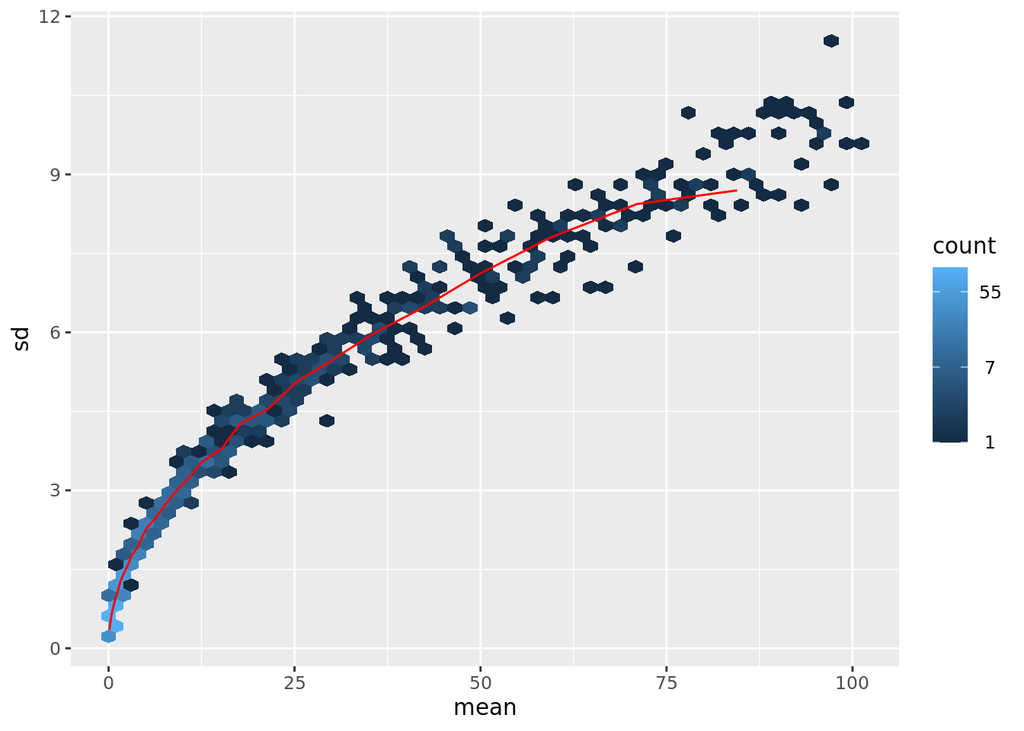

```r
lambda <- 10^seq(from = -1, to = 2, length = 1000)
cts <- matrix(rpois(1000*100, lambda), ncol = 100)
library("vsn")
#install.packages('hexbin')
library('hexbin')
meanSdPlot(cts, ranks = FALSE)
## Found more than one class "simpleUnit" in cache; using the first, from namespace 'ggbio'
## Also defined by 'hexbin'
## Found more than one class "simpleUnit" in cache; using the first, from namespace 'ggbio'
## Also defined by 'hexbin'
```

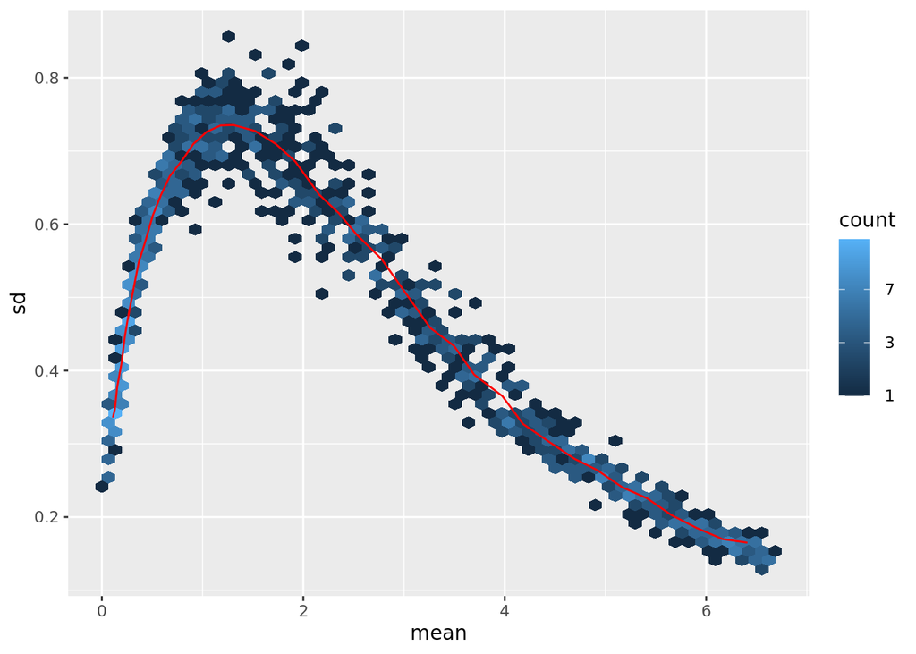

```r
log.cts.one <- log2(cts + 1)
meanSdPlot(log.cts.one, ranks = FALSE)
```

```r
# two possible transformation
# variance stabilizing transformation (vst) recommended for large datasets (n > 30)
vsd <- vst(dds, blind = FALSE)
head(assay(vsd), 3)
```

```
##                 SRR1039508 SRR1039509 SRR1039512 SRR1039513 SRR1039516
## ENSG00000000003   9.742074   9.430420   9.867627   9.645845  10.183143
## ENSG00000000419   9.333669   9.581707   9.486145   9.523093   9.427283
## ENSG00000000457   8.765274   8.698449   8.651473   8.732426   8.592787
##                 SRR1039517 SRR1039520 SRR1039521
## ENSG00000000003   9.880416  10.010366   9.639782
## ENSG00000000419   9.574860   9.325999   9.509246
## ENSG00000000457   8.702674   8.761945   8.724101
```

```r
# regularized-logarithm transformation (rlog) reccommended for smaller datasets (n < 30)
rld <- rlog(dds, blind = FALSE)
head(assay(rld), 3)
```

```
##                 SRR1039508 SRR1039509 SRR1039512 SRR1039513 SRR1039516
## ENSG00000000003   9.385681   9.052599   9.516877   9.285335   9.839093
## ENSG00000000419   8.869611   9.138274   9.036117   9.075296   8.972125
## ENSG00000000457   7.961373   7.881385   7.824075   7.921493   7.751690
##                 SRR1039517 SRR1039520 SRR1039521
## ENSG00000000003   9.530313   9.663260   9.277695
## ENSG00000000419   9.131828   8.861529   9.060906
## ENSG00000000457   7.886441   7.957126   7.912125
```

```r
# blind, treatment group is not considered
```

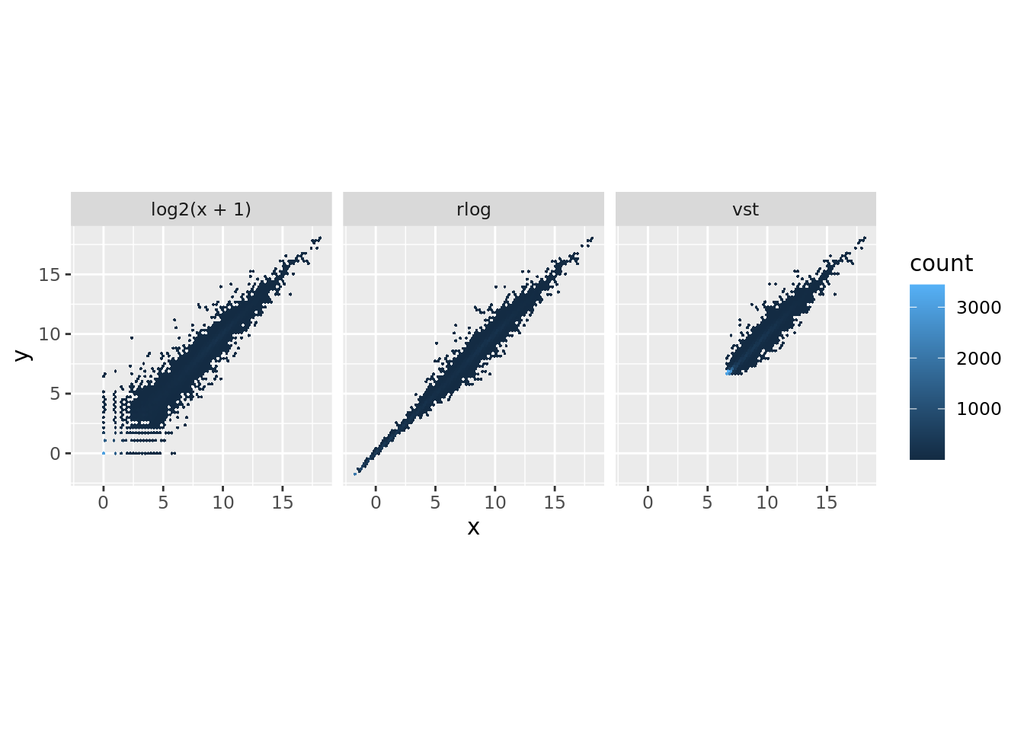

```r
# compare transformation graphically
library("dplyr")
library("ggplot2")

dds <- estimateSizeFactors(dds)

df <- bind_rows(
  as.data.frame(log2(counts(dds, normalized=TRUE)[, 1:2]+1)) %>%
         mutate(transformation = "log2(x + 1)"),
  as.data.frame(assay(vsd)[, 1:2]) %>% mutate(transformation = "vst"),
  as.data.frame(assay(rld)[, 1:2]) %>% mutate(transformation = "rlog"))

colnames(df)[1:2] <- c("x", "y")

ggplot(df, aes(x = x, y = y)) + geom_hex(bins = 80) +
  coord_fixed() + facet_grid( . ~ transformation)
```

```r
sampleDists <- dist(t(assay(vsd)))
sampleDists
```

```
##            SRR1039508 SRR1039509 SRR1039512 SRR1039513 SRR1039516 SRR1039517
## SRR1039509   44.08478
## SRR1039512   36.82952   51.50926
## SRR1039513   59.23174   43.11327   47.21641
## SRR1039516   41.08424   54.79377   40.18856   59.72262
## SRR1039517   59.08409   47.46042   54.13979   46.36635   44.74738
## SRR1039520   37.27578   54.00938   34.56797   55.44564   42.81024   58.22766
## SRR1039521   59.26716   42.84573   54.13120   35.24746   60.64298   47.80456
##            SRR1039520
## SRR1039509
## SRR1039512
## SRR1039513
## SRR1039516
## SRR1039517
## SRR1039520
## SRR1039521   48.24754
```

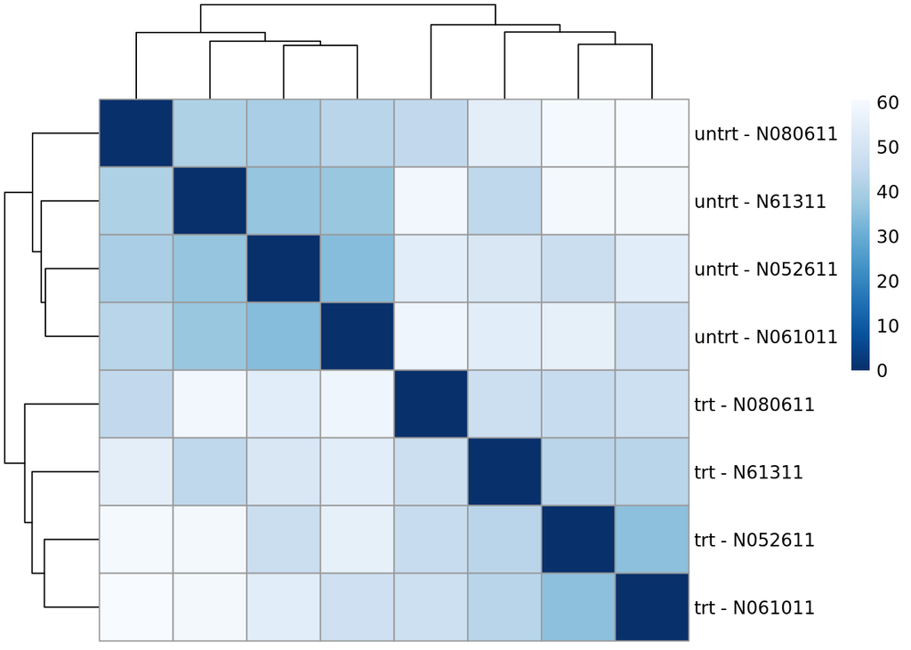

```r
library("pheatmap")
library("RColorBrewer")
sampleDistMatrix <- as.matrix( sampleDists )
rownames(sampleDistMatrix) <- paste( vsd$dex, vsd$cell, sep = " - " )
colnames(sampleDistMatrix) <- NULL
colors <- colorRampPalette( rev(brewer.pal(9, "Blues")) )(255)
pheatmap(sampleDistMatrix,
         clustering_distance_rows = sampleDists,
         clustering_distance_cols = sampleDists,
         col = colors)
## Found more than one class "unit" in cache; using the first, from namespace 'ggbio'
## Also defined by 'hexbin'
## Found more than one class "simpleUnit" in cache; using the first, from namespace 'ggbio'
## Also defined by 'hexbin'
```

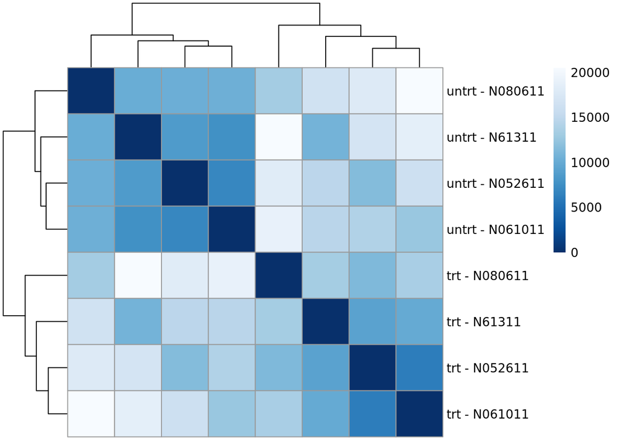

```r
library("PoiClaClu")
poisd <- PoissonDistance(t(counts(dds)))

samplePoisDistMatrix <- as.matrix( poisd$dd )
rownames(samplePoisDistMatrix) <- paste( dds$dex, dds$cell, sep=" - " )
colnames(samplePoisDistMatrix) <- NULL
pheatmap(samplePoisDistMatrix,
         clustering_distance_rows = poisd$dd,
         clustering_distance_cols = poisd$dd,
         col = colors)
```

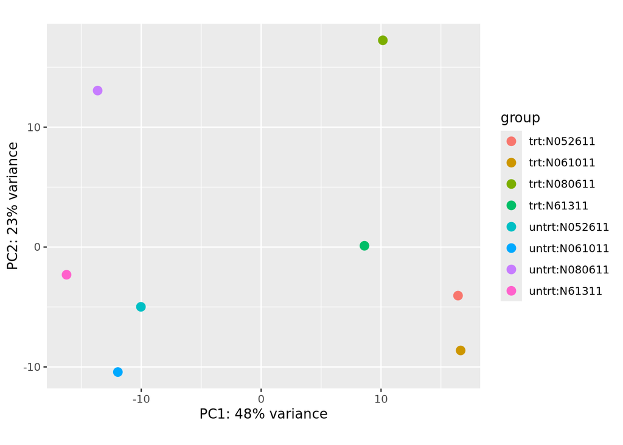

```r
plotPCA(vsd, intgroup = c("dex", "cell"))
## using ntop=500 top features by variance
```

```r
pcaData <- plotPCA(vsd, intgroup = c( "dex", "cell"), returnData = TRUE)
## using ntop=500 top features by variance
```

```r
pcaData
```

```
##                   PC1         PC2         group   dex    cell       name
## SRR1039508 -16.228435  -2.3110688  untrt:N61311 untrt  N61311 SRR1039508
## SRR1039509   8.618864   0.1055443    trt:N61311   trt  N61311 SRR1039509
## SRR1039512 -10.025968  -4.9857836 untrt:N052611 untrt N052611 SRR1039512
## SRR1039513  16.424047  -4.0524552   trt:N052611   trt N052611 SRR1039513
## SRR1039516 -13.635225  13.0513834 untrt:N080611 untrt N080611 SRR1039516
## SRR1039517  10.153386  17.2437947   trt:N080611   trt N080611 SRR1039517
## SRR1039520 -11.948262 -10.4259788 untrt:N061011 untrt N061011 SRR1039520
## SRR1039521  16.641592  -8.6254361   trt:N061011   trt N061011 SRR1039521
```

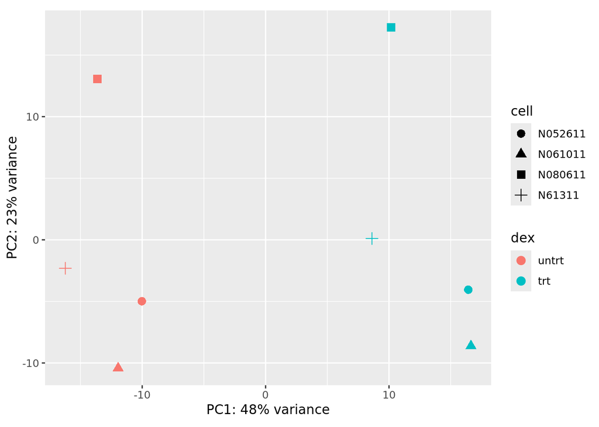

```r
percentVar <- round(100 * attr(pcaData, "percentVar"))
ggplot(pcaData, aes(x = PC1, y = PC2, color = dex, shape = cell)) +
  geom_point(size =3) +
  xlab(paste0("PC1: ", percentVar[1], "% variance")) +
  ylab(paste0("PC2: ", percentVar[2], "% variance")) +
  coord_fixed()
```

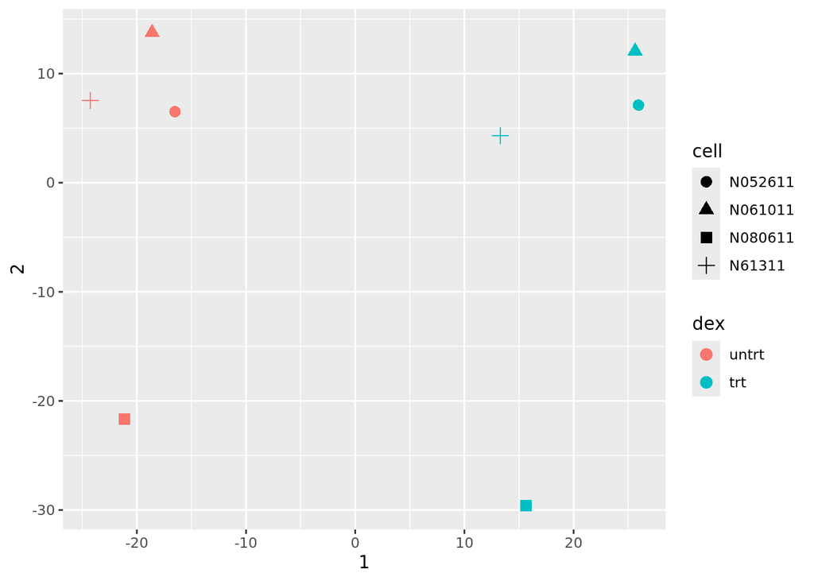

```r
mds <- as.data.frame(colData(vsd))  %>%
         cbind(cmdscale(sampleDistMatrix))
ggplot(mds, aes(x = `1`, y = `2`, color = dex, shape = cell)) +
  geom_point(size = 3) + coord_fixed()
```

## Differential expression analysis

```r
colData(dds)
## DataFrame with 8 rows and 10 columns
##            SampleName     cell      dex    albut        Run avgLength
##              <factor> <factor> <factor> <factor>   <factor> <integer>
## SRR1039508 GSM1275862  N61311     untrt    untrt SRR1039508       126
## SRR1039509 GSM1275863  N61311     trt      untrt SRR1039509       126
## SRR1039512 GSM1275866  N052611    untrt    untrt SRR1039512       126
## SRR1039513 GSM1275867  N052611    trt      untrt SRR1039513        87
## SRR1039516 GSM1275870  N080611    untrt    untrt SRR1039516       120
## SRR1039517 GSM1275871  N080611    trt      untrt SRR1039517       126
## SRR1039520 GSM1275874  N061011    untrt    untrt SRR1039520       101
## SRR1039521 GSM1275875  N061011    trt      untrt SRR1039521        98
##            Experiment    Sample    BioSample sizeFactor
##              <factor>  <factor>     <factor>  <numeric>
## SRR1039508  SRX384345 SRS508568 SAMN02422669   1.023648
## SRR1039509  SRX384346 SRS508567 SAMN02422675   0.896167
## SRR1039512  SRX384349 SRS508571 SAMN02422678   1.179486
## SRR1039513  SRX384350 SRS508572 SAMN02422670   0.670054
## SRR1039516  SRX384353 SRS508575 SAMN02422682   1.177671
## SRR1039517  SRX384354 SRS508576 SAMN02422673   1.399036
## SRR1039520  SRX384357 SRS508579 SAMN02422683   0.920779
## SRR1039521  SRX384358 SRS508580 SAMN02422677   0.944514
```

```r
design(dds)
## ~cell + dex
```

> *“This function will print out a message for the various steps it performs. These are described in more detail in the manual page for DESeq, which can be accessed by typing ?DESeq. Briefly these are: the estimation of size factors (controlling for differences in the sequencing depth of the samples), the estimation of dispersion values for each gene, and fitting a generalized linear model.”*

A good explanation of different normalization methods can be found [here](https://hbctraining.github.io/DGE_workshop/lessons/02_DGE_count_normalization.html).

```r
dds <- DESeq(dds)
## using pre-existing size factors
## estimating dispersions
## gene-wise dispersion estimates
## mean-dispersion relationship
## final dispersion estimates
## fitting model and testing
```

```r
res <- results(dds)
res
## log2 fold change (MLE): dex trt vs untrt
## Wald test p-value: dex trt vs untrt
## DataFrame with 29391 rows and 6 columns
##                   baseMean log2FoldChange     lfcSE       stat      pvalue
##                  <numeric>      <numeric> <numeric>  <numeric>   <numeric>
## ENSG00000000003 708.602170     -0.3812539  0.100654  -3.787751 0.000152017
## ENSG00000000419 520.297901      0.2068127  0.112219   1.842944 0.065337210
## ENSG00000000457 237.163037      0.0379206  0.143445   0.264357 0.791504963
## ENSG00000000460  57.932633     -0.0881677  0.287142  -0.307053 0.758803336
## ENSG00000000938   0.318098     -1.3782340  3.499875  -0.393795 0.693732273
## ...                    ...            ...       ...        ...         ...
## ENSG00000273485   1.286448      -0.127098  1.600421 -0.0794154    0.936702
## ENSG00000273486  15.452537      -0.150989  0.486499 -0.3103571    0.756289
## ENSG00000273487   8.163235       1.046408  0.698967  1.4970774    0.134373
## ENSG00000273488   8.584479       0.107831  0.638099  0.1689880    0.865806
## ENSG00000273489   0.275899       1.483726  3.513945  0.4222393    0.672850
##                       padj
##                  <numeric>
## ENSG00000000003 0.00128122
## ENSG00000000419 0.19620790
## ENSG00000000457 0.91119406
## ENSG00000000460 0.89463420
## ENSG00000000938         NA
## ...                    ...
## ENSG00000273485         NA
## ENSG00000273486   0.893661
## ENSG00000273487   0.329057
## ENSG00000273488   0.945183
## ENSG00000273489         NA
```

```r
# or if comparison of interest is not last level
res <- results(dds, contrast=c("dex","trt","untrt"))
summary(res)
```

```
##
## out of 29391 with nonzero total read count
## adjusted p-value < 0.1
## LFC > 0 (up)       : 2607, 8.9%
## LFC < 0 (down)     : 2218, 7.5%
## outliers [1]       : 0, 0%
## low counts [2]     : 11397, 39%
## (mean count < 5)
## [1] see 'cooksCutoff' argument of ?results
## [2] see 'independentFiltering' argument of ?results
```

```r
# significant results
res.05 <- results(dds, alpha = 0.05)
table(res.05$padj < 0.05)
```

```
##
## FALSE  TRUE
## 12829  4026
```

```r
# significant restults with a 2fold increase
resLFC1 <- results(dds, lfcThreshold=1)
table(resLFC1$padj < 0.1)
```

```
##
## FALSE  TRUE
## 18874   260
```

```r
results(dds, contrast = c("cell", "N061011", "N61311"))
## log2 fold change (MLE): cell N061011 vs N61311
## Wald test p-value: cell N061011 vs N61311
## DataFrame with 29391 rows and 6 columns
##                   baseMean log2FoldChange     lfcSE       stat    pvalue
##                  <numeric>      <numeric> <numeric>  <numeric> <numeric>
## ENSG00000000003 708.602170      0.3063264  0.143531  2.1342194 0.0328248
## ENSG00000000419 520.297901     -0.0540467  0.159716 -0.3383924 0.7350675
## ENSG00000000457 237.163037      0.0163084  0.203026  0.0803267 0.9359774
## ENSG00000000460  57.932633      0.2791270  0.400667  0.6966552 0.4860186
## ENSG00000000938   0.318098      0.0000000  4.997580  0.0000000 1.0000000
## ...                    ...            ...       ...        ...       ...
## ENSG00000273485   1.286448     -2.3214126  2.352916 -0.9866108  0.323833
## ENSG00000273486  15.452537     -0.0727158  0.711891 -0.1021445  0.918642
## ENSG00000273487   8.163235     -0.0269347  1.005075 -0.0267987  0.978620
## ENSG00000273488   8.584479      1.0958476  0.898948  1.2190330  0.222832
## ENSG00000273489   0.275899      0.0000000  4.997580  0.0000000  1.000000
##                      padj
##                 <numeric>
## ENSG00000000003  0.214730
## ENSG00000000419  0.935494
## ENSG00000000457  0.989390
## ENSG00000000460  0.846164
## ENSG00000000938        NA
## ...                   ...
## ENSG00000273485        NA
## ENSG00000273486  0.985421
## ENSG00000273487        NA
## ENSG00000273488        NA
## ENSG00000273489        NA
```

```r
# filter genes to an FDR of 10%
sum(res$padj < 0.1, na.rm=TRUE)
```

```
## [1] 4825
```

```r
resSig <- subset(res, padj < 0.1)
head(resSig[ order(resSig$log2FoldChange), ])
## log2 fold change (MLE): dex trt vs untrt
## Wald test p-value: dex trt vs untrt
## DataFrame with 6 rows and 6 columns
##                  baseMean log2FoldChange     lfcSE      stat      pvalue
##                 <numeric>      <numeric> <numeric> <numeric>   <numeric>
## ENSG00000128285   6.62474       -5.32591  1.257816  -4.23425 2.29319e-05
## ENSG00000267339  26.23357       -4.61155  0.673094  -6.85127 7.31984e-12
## ENSG00000019186  14.08760       -4.32591  0.857768  -5.04321 4.57776e-07
## ENSG00000183454   5.80417       -4.26408  1.166877  -3.65426 2.57921e-04
## ENSG00000146006  46.80760       -4.21185  0.528852  -7.96414 1.66379e-15
## ENSG00000141469  53.43653       -4.12478  1.129798  -3.65091 2.61317e-04
##                        padj
##                   <numeric>
## ENSG00000128285 2.37557e-04
## ENSG00000267339 2.04842e-10
## ENSG00000019186 6.60463e-06
## ENSG00000183454 2.04722e-03
## ENSG00000146006 7.14248e-14
## ENSG00000141469 2.06961e-03
```

# Plotting results

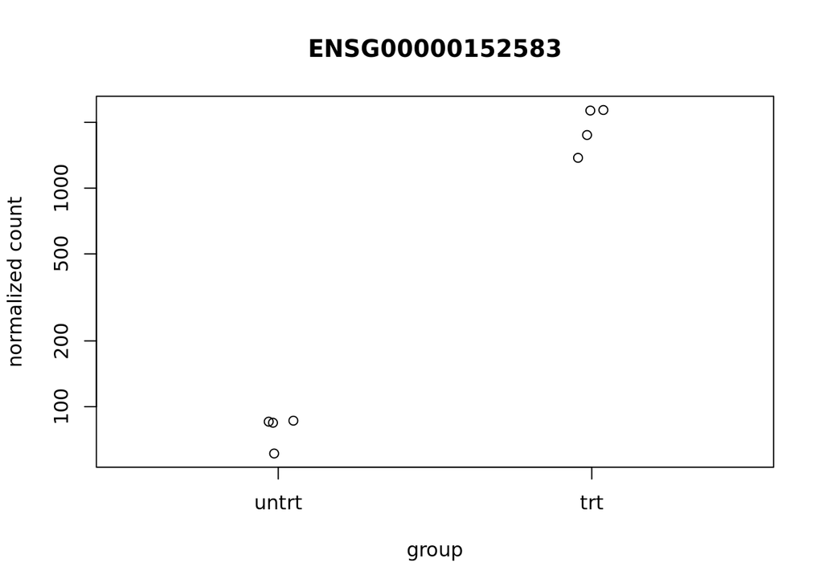

```r
topGene <- rownames(res)[which.min(res$padj)]
plotCounts(dds, gene = topGene, intgroup=c("dex"))
```

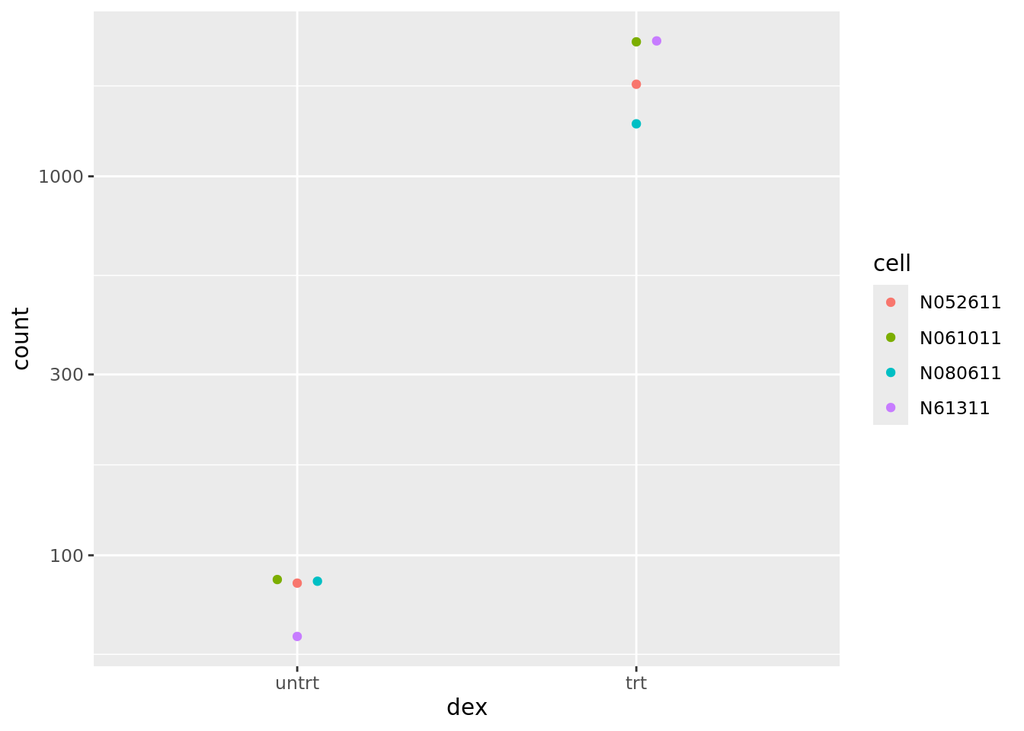

```r
geneCounts <- plotCounts(dds, gene = topGene, intgroup = c("dex","cell"),
                         returnData = TRUE)
ggplot(geneCounts, aes(x = dex, y = count, color = cell)) +
  scale_y_log10() +  geom_beeswarm(cex = 3)
```

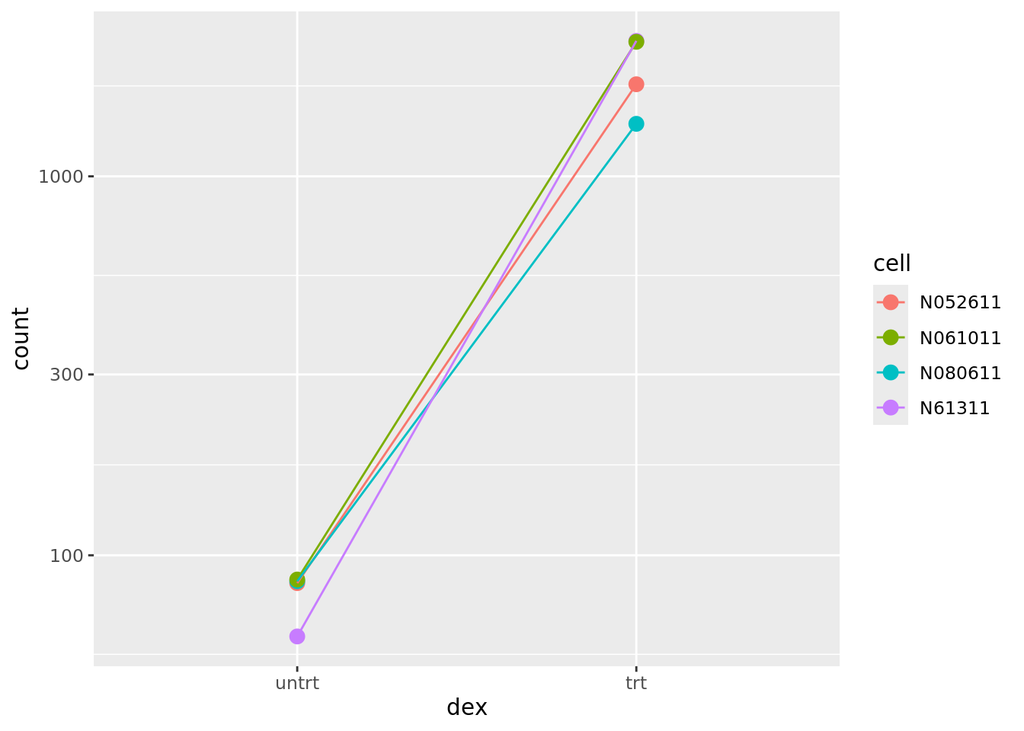

```r
ggplot(geneCounts, aes(x = dex, y = count, color = cell, group = cell)) +
  scale_y_log10() + geom_point(size = 3) + geom_line()
```

Log fold change shrinkage for visualization and ranking is often recommended as described [here](https://bioconductor.org/packages/devel/bioc/vignettes/DESeq2/inst/doc/DESeq2.html#log-fold-change-shrinkage-for-visualization-and-ranking)

```r
library("apeglm")
resultsNames(dds)
```

```
## [1] "Intercept"               "cell_N061011_vs_N052611"
## [3] "cell_N080611_vs_N052611" "cell_N61311_vs_N052611"
## [5] "dex_trt_vs_untrt"
```

```r
res <- lfcShrink(dds, coef="dex_trt_vs_untrt", type="apeglm")
## using 'apeglm' for LFC shrinkage. If used in published research, please cite:
##     Zhu, A., Ibrahim, J.G., Love, M.I. (2018) Heavy-tailed prior distributions for
##     sequence count data: removing the noise and preserving large differences.
##     Bioinformatics. https://doi.org/10.1093/bioinformatics/bty895
```

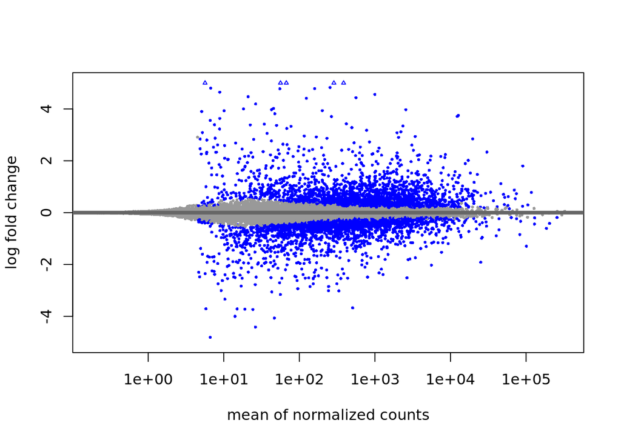

```r
DESeq2::plotMA(res, ylim = c(-5, 5))
```